# DSA3361 Group Project

Team 17

# Introduction

The primary goal of this project is to make predictions on HDB resale price based on a number of factors. All data used in this project has been extracted from data.gov.sg.

To give a brief summary: Our analysis identified several critical factors influencing the resale prices of HDB flats in Singapore, namely location, floor area, and macroeconomic factors such as interest rate and consumer price index for housing & utilities.

Model Performance and Predictive Accuracy: Through comparative analysis, advanced machine learning models such as Random Forest and XGBoost demonstrated superior predictive performance over linear models with regularization like Lasso, Ridge, and Elastic Net. These models not only achieved higher accuracy but also effectively captured complex, non-linear relationships within the data, providing more reliable price estimates.

This study extends the existing discourse on HDB resale pricing by integrating advanced machine learning techniques alongside conventional linear models. By employing models like XGBoost and MLP, the research challenges the reliance on linear assumptions prevalent in previous studies, offering a more nuanced understanding of the factors affecting property prices. Additionally, we further consider potential large variations in data due to unforeseen events such as COVID-19. Data during and before the COVID-19 period was hence excluded from this study and only data from 2022 onwards was included for analysis and model training.

# Data Preparation

### Import Data

We explore resale flat prices (based on registration date) from 2022 to 2024 August. We arbitrarily set 2022 as a start date for this project as it is the period after COVID-19, thus allowing us to avoid large potential irregularities in data. We filter the dates for our dataset after joining of relevant data to be explored.

```r
resale2017 <-
  read.csv("Resale flat prices based on registration date from Jan-2017 onwards.csv",
           stringsAsFactors = T)
```

### Merging and Cleaning Data

```r
# We first conduct preliminary data cleaning

resale_clean <- resale2017 %>%
  mutate(month = ym(month)) %>%
  mutate(remaining_lease = as.numeric(substr(remaining_lease, 1, 2)))

cat("Number of missing entries:",
    sum(is.na(resale_clean)), "\n")
```

```
## Number of missing entries: 0
```

```r
cat("Number of duplicate entries:",
    sum(duplicated(resale_clean)), "\n")
```

```
## Number of duplicate entries: 359
```

We see that there are a number of duplicate entries in the data. However, these duplicate entries may be purely coincidental, with houses in the same block and storey range being sold for the same price. Ultimately, we decide to keep these entries as we have no grounds to remove them without further information (e.g. postal code and unit number to identify the exact house being sold).

### Joining Data

From inspecting the data, we note some potentially important factors such as size, remaining lease years, location etc. in determining resale value. Before analyzing these factors, we pull in additional pieces of information which we have confidence that are important in determining HDB resale value as well, in order to build a better model to predict prices. These factors are CPI, and Bank Interest Rates (specifically, the Singapore Overnight Rate Average).

We first load in the relevant data from data.gov.sg.

```r
interest <- read.csv("CurrentBanksInterestRatesEndOfPeriodMonthly.csv",
                   stringsAsFactors = T)
cpi <- read.csv("ConsumerPriceIndexCPI2019AsBaseYearMonthly.csv",
              stringsAsFactors = T)
```

We then cleaned and reformatted the data sets to allow for subsequent joining with HDB resale data.

```r
interest_clean <- interest %>%
  filter(DataSeries == "Singapore Overnight Rate Average") %>%
  mutate(across(X2024Sep:X1988Jan, as.character))%>%
  mutate(across(X2024Sep:X1988Jan, as.numeric))%>%
  pivot_longer(X2024Sep:X1988Jan,names_to = "yrmonth", values_to="interest_rate") %>%
  mutate(yrmonth = str_replace(yrmonth, "X", "")) %>%
  mutate(yrmonth = ym(yrmonth))

cpi_clean <- cpi %>%
  filter(DataSeries == "    Housing & Utilities") %>%
  mutate(across(X2024Sep:X1961Jan, as.character)) %>%
  mutate(across(X2024Sep:X1961Jan, as.numeric)) %>%
  pivot_longer(X2024Sep:X1961Jan, names_to = "yrmonth", values_to = "CPI_housing") %>%
  mutate(yrmonth = str_replace(yrmonth, "X", "")) %>%
  mutate(yrmonth = ym(yrmonth))
```

Lastly, we join the data obtained based on interest and CPI with the HDB resale data, and filter for the relevant dates up to August 31.

```r
resale_total <- resale_clean %>%
  left_join(interest_clean, by = c("month" = "yrmonth")) %>%
  left_join(cpi_clean, by = c("month" = "yrmonth")) %>%
  select(-DataSeries.x, -DataSeries.y)

resale_aug <- resale_total%>%
  filter(month >= "2022-01-01", month < "2024-09-01")
```

# Exploratory Data Analysis

### Numerical Variables

Resale price is a numerical response variable, and numerical predictor variables of interest include floor area, remaining lease, interest rate and CPI. We plot histograms of these variables to examine their distribution.

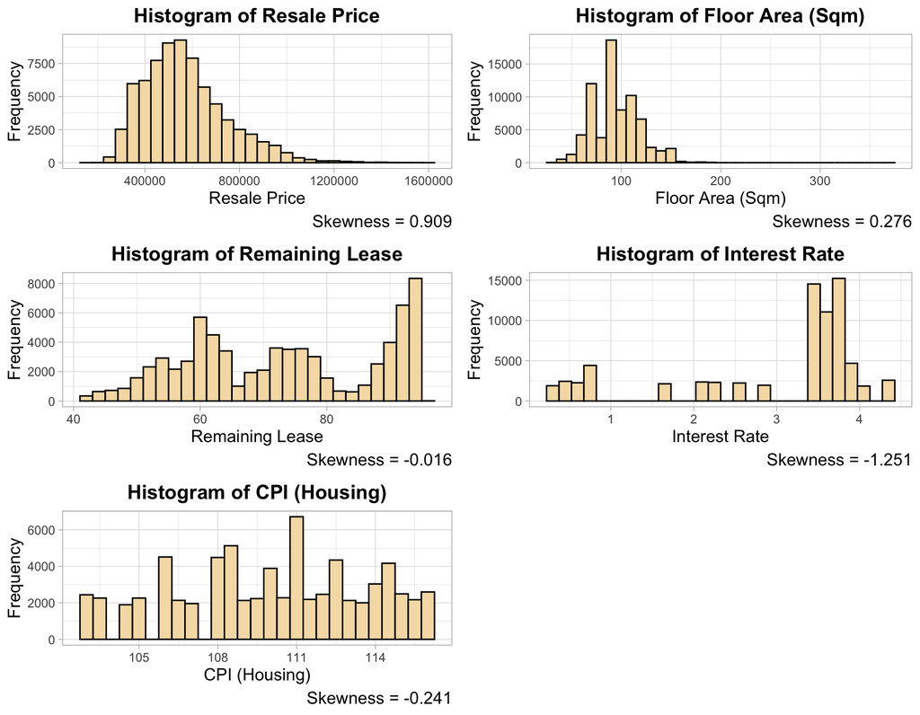

```r
numvars <- data.frame(
  variables = c("resale_price", "floor_area_sqm", "remaining_lease",
             "interest_rate", "CPI_housing"),
  labels = c("Resale Price", "Floor Area (Sqm)", "Remaining Lease",
                  "Interest Rate", "CPI (Housing)"),
  binwidths = c(5*10^4, 10, 2, 0.15, 0.5)
)

numvars_plotlist <- list()

for (i in 1:nrow(numvars)) {
  numvars_plotlist[[i]] <-
    ggplot(resale_aug, aes_string(x = numvars[i, 1])) +
    geom_histogram(binwidth = numvars[i,3],
                   fill = "wheat", color = "black") +
    labs(x = numvars[i, 2], y = "Frequency",
         title = paste0("Histogram of ", numvars[i, 2]),
         caption = paste0("Skewness = ",
                          round(skewness(resale_aug[[numvars[i, 1]]]), 3))) +
    theme_light() +
    theme(plot.title = element_text(size = 14, face = "bold", hjust = 0.5),
          plot.caption = element_text(size = 12),
          axis.title = element_text(size = 12))
}

do.call(grid.arrange, c(numvars_plotlist, ncol = 2))
```

Resale price seems to be slightly right-skewed, with floor area following an approximately normal distribution. Remaining lease and CPI seem to have a multimodal distribution with multiple peaks. Interest rate is left-skewed, with the highest frequencies around the 3.5-4 range.

Next, we plotted a heatmap to visualize the correlation values between the numerical variables.

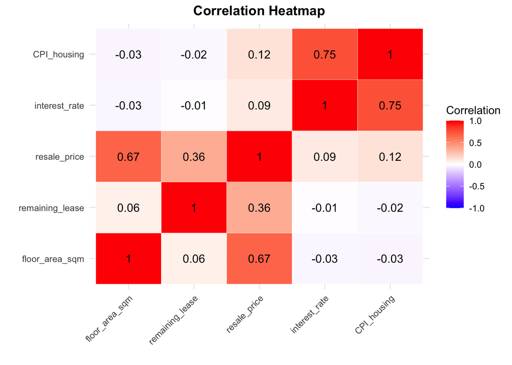

```r
corr_matrix <- cor(resale_aug[,c(7,10:13)])

melted_corr <- melt(corr_matrix)

ggplot(data = melted_corr, aes(x = Var1, y = Var2, fill = value)) +
  geom_tile(color = "white") +
  geom_text(aes(label = round(value, 2)), color = "black", size = 4) +
  scale_fill_gradient2(low = "blue", high = "red", mid = "white",
                       midpoint = 0, limit = c(-1, 1),
                       space = "Lab", name = "Correlation") +
  theme_minimal() +
  theme(plot.title = element_text(face = "bold", hjust = 0.5),
        axis.text.x = element_text(angle = 45, vjust = 1, hjust = 1)) +
  labs(title = "Correlation Heatmap", x = "", y = "")
```

We see that there is a moderate positive correlation between the house size represented by floor_area_sqm and resale price, as well as a weak positive correlation between remaining lease and resale price. Interest rate and CPI also have a strong positive correlation, which could possibly lead to multicollinearity.

The correlations and relationship between the numerical variables can also be observed from the corresponding scatter plots.

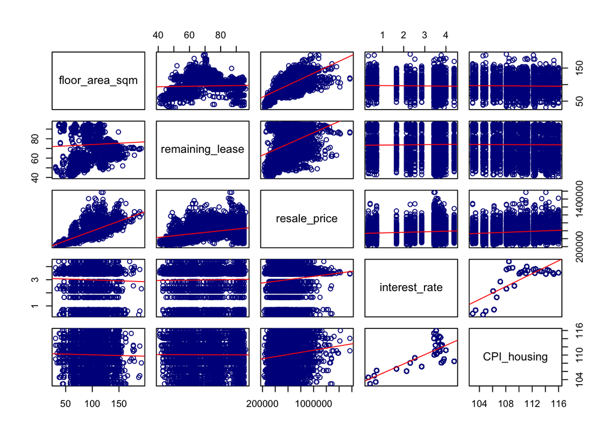

```r
scatter_with_line <- function(x, y) {
  points(x, y, col = "darkblue")
  abline(lm(y ~ x), col = "red")
}

set.seed(123)
pairs(sample_n(resale_aug[, c(7, 10:13)], 5000),
      panel = scatter_with_line)
```

### Categorical Variables

We then explored categorical variables such as town, storey range, flat type and flat model.

We plot boxplots to visualize how the distribution of resale price changes across the variables.

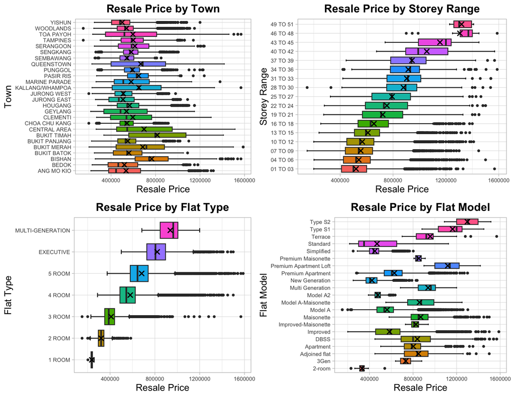

```r
catvars <- c("town", "storey_range", "flat_type", "flat_model")
catvars_labs <- c("Town", "Storey Range", "Flat Type", "Flat Model")
catvars_plotlist <- list()

for (i in 1:length(catvars)) {
  catvars_plotlist[[i]] <-
    ggplot(resale_aug, aes_string(x = "resale_price",
                                   y = catvars[i])) +
    stat_boxplot(geom = 'errorbar', width = 0.2) +
    geom_boxplot(aes_string(fill = catvars[i]),
                 outlier.size = 1) +
    stat_summary(fun = "mean", shape = 4) +
    labs(x = "Resale Price", y = catvars_labs[i],
         title = paste0("Resale Price by ", catvars_labs[i])) +
    theme_light() +
    theme(plot.title = element_text(size = 14, face = "bold", hjust = 0.5),
          axis.title = element_text(size = 12),
          axis.text = element_text(size = 7),
          legend.position = "none")
}

do.call(grid.arrange, c(catvars_plotlist, ncol = 2))
```

We see that the distribution of resale price increases with a higher storey range, and a larger number of rooms under flat type. Its distribution also varies according to the town and flat model of the house. We should consider these 4 categorical variables to investigate if they improve the predictive power of our model. However, upon further inspection, we also see that flat_model and flat_type both contain the same category “Multi-Generation” with similar distributions, which we must address subsequently to prevent perfect multicollinearity.

### Baseline Linear Model and Multicollinearity

We first build a baseline multiple linear regression model. However, to address the “Multi-Generation” category represented in both the flat_type and flat_model, we decide to drop one of the variables. We hence build a linear model with each of these variables to determine which variable should be dropped. Additionally, we remove additional factors that we deem insignificant or are not in use for our modelling, such as street name, block number, date, and lease commence date (which is already represented by remaining lease).

```r
options(scipen = 999)

lm_flatmodel <- lm(resale_price ~. -month -block -street_name
                   -lease_commence_date -flat_type, resale_aug)
summary_flatmodel <- summary(lm_flatmodel)
adj_r_squared_flatmodel <- summary_flatmodel$adj.r.squared
cat("Adjusted R-squared for lm_flatmodel:",
    adj_r_squared_flatmodel, "\n")
```

```
## Adjusted R-squared for lm_flatmodel: 0.8856285
```

```r
lm_flattype<- lm(resale_price ~. -month -block -street_name
                 -lease_commence_date -flat_model, resale_aug)
summary_flattype <- summary(lm_flattype)
adj_r_squared_flattype <- summary_flattype$adj.r.squared
cat("Adjusted R-squared for lm_flattype:",
    adj_r_squared_flattype, "\n")
```

```
## Adjusted R-squared for lm_flattype: 0.8688217
```

As the adjusted R-squared value for the model including flat_model is higher, we will choose lm_flatmodel as our linear model and drop the variable flat_type in our dataset instead.

```r
resale_full<- resale_aug %>%
  select(-flat_type)
```

We move on to investigate if multicollinearity and influential points exist for the model of choice.

```r
vif(lm_flatmodel)
```

```
##                      GVIF Df GVIF^(1/(2*Df))
## town             5.644847 25        1.035221
## storey_range     1.747614 16        1.017598
## floor_area_sqm   1.953489  1        1.397673
## flat_model      10.583933 20        1.060758
## remaining_lease  2.382367  1        1.543492
## interest_rate    2.305314  1        1.518326
## CPI_housing      2.310913  1        1.520169
```

We see that there is high multicollinearity for town and flat_model, hence suggesting that further manipulation must be done to optimize this model, which will be done through subsequent regularization.

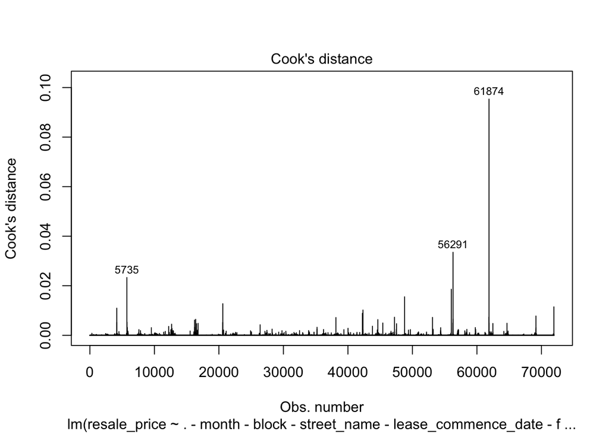

```r
plot(lm_flatmodel, which = 4)
```

```r
cooksD <- cooks.distance(lm_flatmodel)
outlier <- cooksD > 4 / (length(cooksD)-(7+1))
table(outlier)
```

```
## outlier
## FALSE  TRUE
## 68023  3908
```

```r
resale_noout <- resale_full %>%
  mutate(CooksD = cooksD, Outlier = outlier) %>%
  filter(Outlier == F)

filtered_noout <- resale_noout %>% select(-month,-block,-street_name
                  ,-lease_commence_date,-CooksD,-Outlier)

lm_no_outliers <- lm(resale_price ~., filtered_noout)
summary_noout <- summary(lm_no_outliers)
adj_r_squared_noout <- summary_noout$adj.r.squared

cat("Adjusted R-squared for lm_no_outliers:",
    adj_r_squared_noout, "\n")
```

```
## Adjusted R-squared for lm_no_outliers: 0.9021004
```

After calculating the Cook’s distance, while there were no points that were above a distance of 0.5, there were 3908 observations with Cook’s distance greater than 4/n-(p+1), suggesting that these points may potentially be outliers. Nonetheless, the Cook’s distance values observed were generally low, all under 0.1. Removal of these points allowed for a marginal improvement of the adjusted R-squared value (from 0.886 to 0.902). Since Cook’s distances are generally low and removing influential points did not lead to a largely significant increase in model performance, we decided to retain them in the subsequent analysis.

# Models

In this section, we build a Multiple Linear Regression model, and incorporate regularization techniques to reduce overfitting, and address multicollinearity. The performance of these models will subsequently be evaluated.

### MLR & Regularization Methods

We split the data for our subsequent models into train test sets. For our models, we only remove the non-critical values such as month, block, street name, and lease date, as done previously.

```r
set.seed(123)
rate <- 0.8
train.size <- round(nrow(resale_full) * rate)
sample <- sample(nrow(resale_full), train.size)

training_full <- resale_full[sample, ]
training <- training_full %>%
  select(-month, -block, -street_name, -lease_commence_date)

test_full <- resale_full[-sample, ]
test <- test_full %>%
  select(-month, -block, -street_name, -lease_commence_date)
```

### MLR

```r
lm_model <- lm(resale_price~., data=training)
```

### Regularization Methods

Converting models into train and test matrices, and splitting to predictors and target values

```r
train.x <- model.matrix(resale_price ~ ., data = training)[, -1]
train.y <- training$resale_price
test.x  <- model.matrix(resale_price ~ ., data = test)[, -1]
test.y  <- test$resale_price
```

### Ridge Regression

Using cross validation to get lambda min and training the ridge regression model

```r
cv_ridge <- cv.glmnet(train.x, train.y, alpha = 0, type.measure = "mse")
glm_Ridge <- glmnet(train.x, train.y, alpha = 0, lambda = cv_ridge$lambda.min)
```

### LASSO Regression

Using cross validation to get lambda min and training the lasso regression model

```r
cv_LASSO <- cv.glmnet(train.x, train.y, alpha = 1, type.measure = "mse")
glm_LASSO <- glmnet(train.x, train.y, alpha = 1, lambda = cv_LASSO$lambda.min)
```

### Elastic Net Regression

Define a function that runs cross validation on a specified alpha.

```r
generate_cvmodels <- function (x) {
  set.seed(123)
  return(cv.glmnet(train.x, train.y,
                  type.measure = "mse", alpha = x/10))
}
```

Running the above function 11 times from alpha = 0 to 1 in intervals of 0.1.

```r
cv_models <- lapply(0:10, generate_cvmodels)
# Generate cross-validation mses for all 11 models
(cv_error <- unlist(lapply(cv_models,
                          function(x) x$cvm[x$lambda == x$lambda.min] )))
```

```
##  [1] 3944967327 3625672892 3626595698 3626687586 3627490972 3627218802
##  [7] 3627057100 3626889460 3626856246 3626830830 3626937957
```

```r
# Return smallest alpha
(which(cv_error == min(cv_error))-1)/10
```

```
## [1] 0.1
```

```r
get_best_model <- function (models, errors) {
  best_n <- which(errors == min(errors))
  return(
    data.frame(
      alpha = (best_n - 1)/10,
      lambda = models[[best_n]]$lambda.min,
      CV_error = errors[best_n]
    )
  )
}

(best_parameter <- get_best_model(cv_models, cv_error))
```

```
##   alpha   lambda   CV_error
## 1   0.1 249.9513 3625672892
```

With these parameters, we build our Elastic Net Regression model

```r
glm_ElaNet <- glmnet(train.x,
                     train.y,
                     alpha = best_parameter$alpha,
                     lambda = best_parameter$lambda)
```

# Model Evaluation

Defining the helper function for evaluating models based on various categories

```r
eval_results <- function(fit, true) {
  actual <- data.matrix(true)
  RSS <- sum((actual - fit)^2)
  TSS <- sum((actual - mean(actual))^2)
  R_square <- 1 - RSS / TSS
  n<-length(fit)
  p<-7
  Adj_Rsquare<-1 - ((1 - R_square)*(n - 1)/(n - p - 1))
  data.frame(
    MSE = MSE(fit, true),
    MAE = MAE(fit, true),
    RMSE = RMSE(fit, true),
    MAPE = MAPE(fit, true),
    R2 = R_square,
    Adj_R2 = Adj_Rsquare
  )
}
```

We evaluate the performance of our models on both train and test data.

```r
# Base MLR
fit_lin_train <- predict(lm_model, newdata = training)
true_lin_train <- training$resale_price
summary_linear_train <- eval_results(fit_lin_train, true_lin_train)

fit_lin_test <- predict(lm_model,newdata = test)
true_lin_test <- test$resale_price
summary_linear_test <- eval_results(fit_lin_test,true_lin_test)

# Regularization Models
true_train <- train.y
true_test <- test.y

# Ridge
fit_Ridge_train <- predict(glm_Ridge, train.x)
summary_Ridge_train <- eval_results(fit_Ridge_train, true_train)
fit_Ridge_test <- predict(glm_Ridge, test.x)
summary_Ridge_test <- eval_results(fit_Ridge_test, true_test)

# LASSO
fit_LASSO_train <- predict(glm_LASSO, train.x)
summary_LASSO_train <- eval_results(fit_LASSO_train, true_train)
fit_LASSO_test <- predict(glm_LASSO, test.x)
summary_LASSO_test <- eval_results(fit_LASSO_test, true_test)

# ElaNet
fit_ElaNet_train <- predict(glm_ElaNet, train.x)
summary_ElaNet_train <- eval_results(fit_ElaNet_train, true_train)
fit_ElaNet_test <- predict(glm_ElaNet, test.x)
summary_ElaNet_test <- eval_results(fit_ElaNet_test, true_test)
```

We create a summary table to evaluate how our 4 models perform across the various error metrics, for both the train and test data sets.

```r
summary_trainperf <- rbind(summary_linear_train, summary_Ridge_train,
                           summary_LASSO_train, summary_ElaNet_train)

rownames(summary_trainperf) <- c("Linear_train", "Ridge_train",
                                 "LASSO_train", "ElaNet_train")

knitr::kable(summary_trainperf, digits = 3)
```

|  | MSE | MAE | RMSE | MAPE | R2 | Adj_R2 |
| --- | --- | --- | --- | --- | --- | --- |
| Linear_train | 3606603803 | 45123.95 | 60055.01 | 0.083 | 0.886 | 0.886 |
| Ridge_train | 3928932836 | 45631.12 | 62681.20 | 0.081 | 0.876 | 0.876 |
| LASSO_train | 3609604220 | 45099.03 | 60079.98 | 0.083 | 0.886 | 0.886 |
| ElaNet_train | 3610276105 | 45057.85 | 60085.57 | 0.083 | 0.886 | 0.886 |

```r
summary_testperf <- rbind(summary_linear_test, summary_Ridge_test,
                           summary_LASSO_test, summary_ElaNet_test)

rownames(summary_testperf) <- c("Linear_test", "Ridge_test",
                                 "LASSO_test", "ElaNet_test")

knitr::kable(summary_testperf, digits = 3)
```

|  | MSE | MAE | RMSE | MAPE | R2 | Adj_R2 |
| --- | --- | --- | --- | --- | --- | --- |
| Linear_test | 3544977446 | 44787.44 | 59539.71 | 0.083 | 0.885 | 0.885 |
| Ridge_test | 3852325824 | 45284.08 | 62067.11 | 0.081 | 0.875 | 0.875 |
| LASSO_test | 3547308121 | 44774.86 | 59559.28 | 0.083 | 0.885 | 0.885 |
| ElaNet_test | 3548074737 | 44738.87 | 59565.72 | 0.083 | 0.885 | 0.885 |

```r
coef(glm_ElaNet)
```

```
## 66 x 1 sparse Matrix of class "dgCMatrix"
##                                            s0
## (Intercept)                      -1225974.057
## townBEDOK                          -20210.104
## townBISHAN                         105008.644
## townBUKIT BATOK                    -97737.900
## townBUKIT MERAH                     99853.201
## townBUKIT PANJANG                 -133819.758
## townBUKIT TIMAH                    202717.473
## townCENTRAL AREA                   102867.024
## townCHOA CHU KANG                 -170248.855
## townCLEMENTI                        20697.654
## townGEYLANG                         44414.235
## townHOUGANG                        -78541.412
## townJURONG EAST                    -93286.822
## townJURONG WEST                   -143365.702
## townKALLANG/WHAMPOA                 65044.770
## townMARINE PARADE                  121913.017
## townPASIR RIS                      -99015.556
## townPUNGGOL                       -123405.826
## townQUEENSTOWN                      97301.822
## townSEMBAWANG                     -156009.211
## townSENGKANG                      -133421.585
## townSERANGOON                        8410.529
## townTAMPINES                       -47296.183
## townTOA PAYOH                       60565.309
## townWOODLANDS                     -151309.177
## townYISHUN                        -113501.854
## storey_range04 TO 06                17790.274
## storey_range07 TO 09                32584.136
## storey_range10 TO 12                40180.997
## storey_range13 TO 15                51923.094
## storey_range16 TO 18                71773.644
## storey_range19 TO 21               103865.618
## storey_range22 TO 24               119042.423
## storey_range25 TO 27               134311.221
## storey_range28 TO 30               167608.378
## storey_range31 TO 33               184673.380
## storey_range34 TO 36               194887.603
## storey_range37 TO 39               206742.146
```

[output cut: 13 more lines]

```
## flat_modelModel A-Maisonette        99205.989
## flat_modelModel A2                   2206.539
## flat_modelMulti Generation          86098.581
## flat_modelNew Generation            12310.337
## flat_modelPremium Apartment          7197.400
## flat_modelPremium Apartment Loft   180939.742
## flat_modelPremium Maisonette        25144.440
## flat_modelSimplified                31535.395
## flat_modelStandard                  -5751.150
## flat_modelTerrace                  294142.053
## flat_modelType S1                  246987.314
## flat_modelType S2                  315845.186
## remaining_lease                      5529.500
## interest_rate                         736.754
## CPI_housing                          8250.095
```

We see that all of the coefficients are non-zero and Elastic Net regression does not perform any feature selection, indicating that all of the coefficients contribute to the predictive power of the model.